# 项目：电影数据集调查

### 研究问题 5

电影上映时间有什么特点？

**# 一年的哪个时间段电影上映最密集**  
**# 哪个月份上映的电影平均票房最高？**  
**# 高票房电影中，首次上映日期，月份分布。哪个月份上映的电影，高票房的比例最高？**  
**# 哪一年上映电影的数量最多，有多少部？**  
**# 每个月份上映的电影，哪个类别电影最多。电影上映的月份和上映类别的分布关系？**

**——一年的哪个时间段电影上映最密集**

```python
# 设置release_date列为索引
df=df.set_index('release_date')
```

```python
# 按12个月份统计所有电影上映情况
_=df.groupby(lambda x:x.month)['id'].count()
```

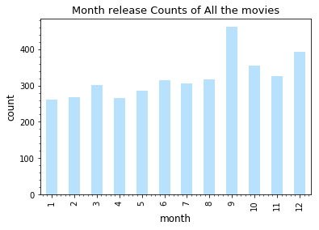

```python
# 所有电影中，按12个月份统计所有电影上映情况的数量分布
df.groupby(lambda x:x.month)['id'].count().plot(kind='bar',color = 'lightskyblue',alpha=0.6);

plt.title('Month release Counts of All the movies',fontsize=13);
plt.xlabel('month',fontsize=12);
plt.ylabel('count',fontsize=12);
plt.minorticks_on();
```

**所有电影中，9月份上映的电影数量最多，9月份上映的电影数量最密集。**

**——哪个月份上映的电影平均票房最高？**

```python
# 按12个月份统计所有电影上映情况平均值
_=df.groupby(lambda x:x.month).mean()
```

```python
# 按12个月份统计所有电影上映情况，平均值最大值是多少
df.groupby(lambda x:x.month)['revenue_adj'].mean().max()
```

```
211007867.80280182
```

```python
# 按12个月份统计所有电影上映情况，平均值最大值是几月份
df.groupby(lambda x:x.month)['revenue_adj'].mean().argmax()
```

```
6
```

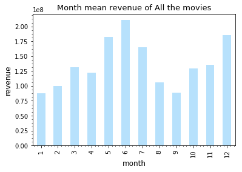

```python
# 按12个月份统计所有电影上映情况的月平均票房分布
df.groupby(lambda x:x.month)['revenue_adj'].mean().plot(kind='bar',color = 'lightskyblue',alpha=0.6);

plt.title('Month mean revenue of All the movies',fontsize=13);
plt.xlabel('month',fontsize=12);
plt.ylabel('revenue',fontsize=12);
plt.minorticks_on();
```

**——高票房电影中，首次上映日期分布。按月份分组**

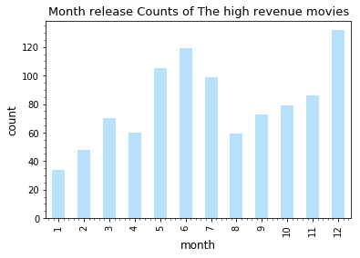

```python
# 按12个月份统计高票房电影上映情况的数量分布
df[df['revenue_adj'] > df['revenue_adj'].quantile(0.75)].groupby(lambda x:x.month)['id'].count().plot(kind='bar',color = 'lightskyblue',alpha=0.6);

plt.title('Month release Counts of The high revenue movies',fontsize=13);
plt.xlabel('month',fontsize=12);
plt.ylabel('count',fontsize=12);
plt.minorticks_on();
```

**高票房电影中，12月份上映的电影数量最多。**

**——哪个月份上映的电影，高票房的比例最高**

```python
# 哪个月份上映的电影高票房的比例最高
proportion=df[df['revenue_adj'] > df['revenue_adj'].quantile(0.75)].groupby(lambda x:x.month)['id'].count()/df.groupby(lambda x:x.month)['id'].count()
```

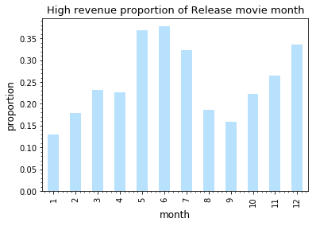

```python
# 哪个月份上映的电影高票房的比例最高
proportion.plot(kind='bar',color = 'lightskyblue',alpha=0.6);

plt.title('High revenue proportion of Release movie month',fontsize=13);
plt.xlabel('month',fontsize=12);
plt.ylabel('proportion',fontsize=12);
plt.minorticks_on();
```

**所有电影中，6月份上映的电影高票房的比例最高。**

——**哪一年上映电影的数量最多，有多少部？**

```python
# 哪年上映的电影数量最多，有多少部？
df.groupby(lambda x:x.year)['id'].count().max()
```

```
199
```

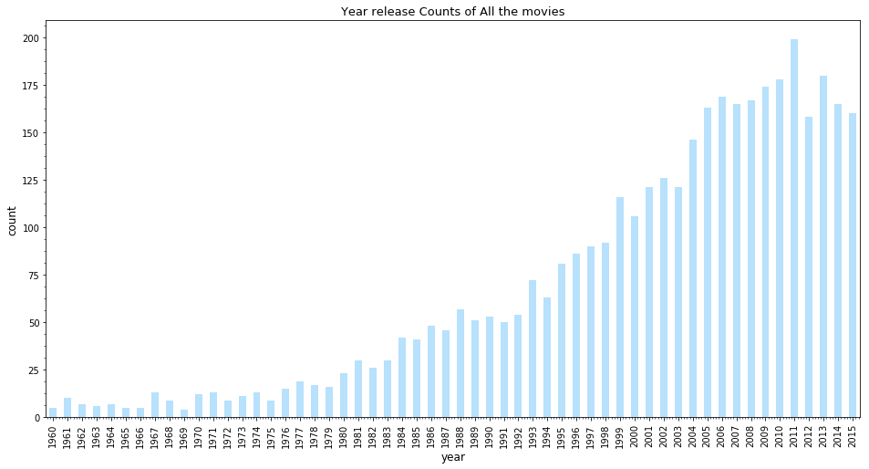

```python
# 按年统计所有电影上映情况的数量分布
df.groupby(lambda x:x.year)['id'].count().plot(kind='bar',color = 'lightskyblue',alpha=0.6,figsize=(16,8));

plt.title('Year release Counts of All the movies',fontsize=13);
plt.xlabel('year',fontsize=12);
plt.ylabel('count',fontsize=12);
plt.minorticks_on();
```

**——每个月份上映的电影，哪个类别电影最多。电影上映的月份和上映类别的关系？**

```python
# 每个月份上映的电影，电影类别数量print(m,list_genres)
for m in np.arange(1,13):
    if m<13:
        set_genres = set()
        for list_keywords in df.query('month==@m')['genres'].str.split('|').values:
            set_genres = set_genres.union(list_keywords)

        dict_genres = dict()
        for s in set_genres: dict_genres[s] = 0
        for list_keywords in df.query('month==@m')['genres'].str.split('|'):
            for s in [s for s in list_keywords if s in set_genres]:
                dict_genres[s] += 1

        list_genres = []
        for k,v in dict_genres.items():
            list_genres.append([k,v])
        list_genres.sort(key = lambda x:x[1], reverse = True)
```

## 结论

**研究问题一：**

**每年最受欢迎的电影类别是哪些？**

**——**电影的种类有20种，分别是：  
'Action', 'Adventure', 'Western', 'Science Fiction', 'Drama', 'Family', 'Comedy', 'Crime', 'Romance', 'War', 'Thriller', 'Fantasy', 'History', 'Mystery', 'Animation', 'Horror', 'Music', 'Documentary', 'TV Movie', 'Foreign'  
只有 'Documentary', 'TV Movie', 'Foreign'不能在高口碑高票房的电影中找到。

**——**不论是所有电影，还是最高口碑高票房的电影，电影类别的数量占比，前四名 从高到低依次是Drama 、Action 、Adventure、Thriller，这四类电影合计占比46%，是大众普遍比较喜欢的类别。

**——**Drama类别电影拍摄数量最多，所以在高票房高口碑电影中占比也高，不能说明Drama是大众最喜欢的电影类型。判断大众每年最喜欢的电影类型，应参考数据每年最受欢迎的电影类别。

**——**每年最受欢迎的电影类别，在56年中所占年数： Action 28 Adventure 9 Drama 7 Crime 6 Animation 3 Comedy 2 Music 1 ，所以大众最喜欢的电影类别是Action动作片。其次，Adventure、Drama、Crime也比较受欢迎。

**附**：

每年口碑和票房最高的电影类别为： 1960 Drama, 1961 Drama, 1962 Drama, 1963 Thriller 1964 Drama, 1965 Romance, Action, Adventure 1966 Action , Adventure ,Drama, 1967 Drama 1968 Drama, 1969 Drama 1970 Drama, 1971 Thriller,Action 1972 Crime,Thriller, Action, 1973 Crime,Drama 1974 Drama, 1975 Drama 1976 Thriller,Drama , 1977 Drama 1978 Drama, 1979 Science Fiction, Drama, 1980 Drama,Thriller,Drama, 1981 Comedy 1982 Drama, 1983 Thriller 1984 Comedy, Action,Drama, 1985 Comedy,Adventure 1986 Drama, 1987 Comedy 1988 Comedy, 1989 Comedy, 1990 Drama, 1991 Thriller,Drama 1992 Drama, 1993 Drama 1994 Drama, 1995 Drama 1996 Drama, 1997 Drama 1998 Drama, 1999 Drama 2000 Drama, 2001 Drama 2002 Drama, 2003 Action 2004 Drama, 2005 Drama 2006 Drama, 2007 Drama 2008 Drama, 2009 Drama 2010 Drama, 2011 Drama 2012 Drama, 2013 Drama 2014 Drama, 2015 Drama

每年最受欢迎的电影类别为： 1960 Drama, 1961 Adventure, 1962 Action, 1963 Action 1964 Action, 1965 Action 1966 Drama, 1967 Adventure 1968 Adventure, 1969 Action 1970 Adventure 1971 Drama 1972 Crime 1973 Animation 1974 Crime 1975 Drama 1976 Crime 1977 Action 1978 Music 1979 Action 1980 Action 1981 Action 1982 Drama 1983 Action 1984 Action 1985 Adventure 1986 Action 1987 Action 1988 Action 1989 Animation 1990 Action 1991 Animation 1992 Crime 1993 Comedy 1994 Crime 1995 Crime 1996 Action 1997 Drama 1998 Comedy 1999 Drama 2000 Action 2001 Action 2002 Action 2003 Action 2004 Adventure 2005 Adventure 2006 Action 2007 Action 2008 Action 2009 Action 2010 Action 2011 Action 2012 Action 2013 Adventure 2014 Adventure 2015 Action

**研究问题二：**

**票房高的电影有哪些特点？**

**——**高票房电影中： 最受欢迎的导演是： Steven Spielberg 21部影片，远超其他导演 排名前一百的导演，大部分拍摄4-5部高票房电影

**——**高票房电影中： 最受欢迎的演员是： Tom Cruise 26部影片 排名前一百的演员，大部分拍摄8-11部高票房电影

**——**高票房电影中： 最受欢迎的制作公司是：Warner Bros.130部影片,与第二名Universal Pictures120部影片差距很小 排名前六的制作公司，拍摄高票房电影数量远超其他公司，拍摄高票房影片数都在60部以上，是高票房电影的发源地 排名前一百的制作公司，大部分拍摄10部左右高票房电影

**——**高票房电影中： 最受欢迎的电影类别是：Action400部影片，占比13.9% 排名前五的电影类别受欢迎程度远超其他类别，总占比达60%。 受欢迎类别的第二至五名分别是：Adventure347部，占比12.1%； Drama328部，占比11.4%； Comedy326部，占比11.4%； Thriller291部，占比10.1%；

**——**高票房电影中: 电影的平均时长是117分钟 最集中的电影时长是110-120分钟 大部分的电影时长集中在90-130分钟

**——**票房最高的电影： Star Wars: The Force Awakens 电影时长136分钟 评分7.5分 上映时间：2015-12-15 导演：J.J. Abrams 主演：Harrison Ford|Mark Hamill|Carrie Fisher|Adam Driver|Daisy Ridley 制作公司： Lucasfilm|Truenorth Productions|Bad Robot 票房实际收入：2,068,178,225$

**研究问题三：**

**所有电影、高票房高口碑的名利双收电影、高票房电影的评分有什么特点？**

**——**所有电影:  
75%位置评分：5.7，中位数评分：6.2，25%位置评分：6.7  
平均分：6.167134  
**——**高票房电影：  
75%位置评分：6，中位数评分：6.4，25%位置评分：7  
平均分：6.454262  
**——**高票房高口碑电影:  
75%位置评分：6.9，中位数评分：7.2，25%位置评分：7.2  
平均分：7.229641  
**——**所有电影—高票房电影—高票房高口碑电影，评分逐渐变高。高票房高口碑电影因为数据选择的是评分75%以上的电影，评分在这三种电影样本中一定是最高，只对比所有电影和高票房电影。

**——**通过对比所有电影和高票房电影的评分分布图：  
不论是所有电影还是高票房电影，最集中的得分都是在6-7分之间，最高得分都没有超过9分。  
高票房电影和所有电影图形的分布形态相似，即使票房高也有得分4分多的电影。高票房的电影中没有得分4分以下的电影。  
所有电影比高票房电影的得分分布范围略大。  
低票房的电影得分主要集中在5-6分之间。

**——**综上推论：电影票房和评分没有必然的相关性。评分低口碑差的电影也有高票房的，但是口碑太差很难高票房。评分低的电影高票房的相对较少。

**研究问题四：**

**高收益率电影、高收益电影、同时高收益率电影和高收益的电影是哪些？有什么特点？**

**——**高收益电影： 平均评分6.489097,平均票房388,535,700美元  
高收益率电影：  
平均评分6.542620,平均票房278,290,900美元  
同时高收益率和高收益的电影：  
平均评分6.654145,平均票房431,187,000美元

**——**通过对比高收益率电影和高收益电影的评分分布图：  
高收益率电影和高收益电影的评分对比，与所有电影和高票房电影的评分对比基本相同。高收益率电影类似所有电影，高收益电影类似高票房电影。  
不论是高收益率电影还是高收益电影，最集中的得分都是在6-7分之间，最高得分都没有超过9分。  
高收益率电影和高收益电影图形的分布形态相似，即使高收益电影也有得分4分多的电影。高收益电影中没有得分4分以下的电影，得分相对较高。  
高收益率的电影得分在3-9分之间都有，说明不论电影口碑如何，都能获得较高的收益率。

**——**电影类别占比远远多于其它的有：  
高收益电影，前五名占比58.4%  
Action 363部，占类别比例13%  
Comedy 339部，占类别比例12.2%  
Drama 331部，占类别比例11.9%  
Adventure 314部，占类别比例11.3%  
Thriller 278部，占类别比例10%

高收益率电影，前六名占比65%  
Drama 412部，占类别比例16.8%  
Comedy 352部，占类别比例14.4%  
Thriller 258部，占类别比例10.5%  
Action 219部，占类别比例8.9%  
Romance 177部，占类别比例7.2%  
Adventure 177部，占类别比例7.2%

高收益高收益率电影，前五名占比58%  
Drama 218部，占类别比例13.9%  
Comedy 218部，占类别比例13.9%  
Action 170部，占类别比例10.9%  
Adventure 157部，占类别比例10%  
Thriller 145部，占类别比例9.3%  
**——**从经济效益角度考虑，首先应从Drama,Comedy,Action,Adventure,Thriller类别中选择，其次,Romance,Family也可以考虑

**——**通过对比，高收益率电影、高收益电影、同时高收益率和高收益电影的票房分布比例：  
高收益电影  
75%_max 871部，占比90.4%  
50%_75% 92部，占比9.6%

高收益率电影  
75%_max 495部，占比51.5%  
50%_75% 252部，占比26.2%  
25%_50% 143部，占比14.9%  
min_25% 72部，占比7.5%

高收益高收益率电影  
75%_max 495部，占比87.3%  
50%_75% 72部，占比12.7%

**——**高收益电影，九成是票房在75%_max的高票房电影。所以，想要获得高收益，必须有比较高的票房。  
高收益率的电影，每个票房等级的都有。各个等级所占比例75%_max的最高，占比五成。其他等级占比依次递减。  
所以，不论电影票房如何，都能获得较高的收益率。票房高的电影，获得高收益率的比例更大。  
高收益高收益率电影，近九成是票房在75%_max的高票房电影。  
所以，既想获得高收益，又想有比较高的收益率，拍摄有高票房电影特点的电影，是不错的选择。

**——**通过对比，高收益率电影、高收益电影、同时高收益率和高收益电影的制作公司分布比例：  
高收益电影  
所有制作公司拍摄的影片数量占比大于1%的有13家  
前二十名制作公司，拍摄的影片数量，占比合计34.4%

高收益率电影  
所有制作公司拍摄的影片数量占比大于1%的有10家  
前二十名制作公司，拍摄的影片数量，占比合计27.7%

高收益高收益率电影  
所有制作公司拍摄的影片数量占比大于1%的有13家  
前二十名制作公司，拍摄的影片数量，占比合计34.4%

**——**高收益电影，拍摄占比远超其他制作公司的，前四名公司：  
Warner Bros. 118部，占比0.042785  
Universal Pictures 113部，占比0.040972  
Paramount Pictures 111部，占比 0.040247  
Twentieth Century Fox Film Corporation 94部，占比0.034083

高收益率的电影，拍摄占比远超其他制作公司的，前四名公司：  
Universal Pictures 101部，占比0.040595  
Paramount Pictures 82部，占比0.032958  
Warner Bros. 65部，占比 0.026125  
Twentieth Century Fox Film Corporation 64部，占比 0.025723

高收益高收益率电影，拍摄占比远超其他制作公司的，前四名公司：  
Universal Pictures 70部，占比 0.046388  
Paramount Pictures 61部，占比0.040424  
Warner Bros. 58部，占比 0.038436  
Twentieth Century Fox Film Corporation 50部，占比0.033135

**——**所以，如果希望拍摄高收益，并且高收益的电影，最佳选择是找Universal Pictures，Paramount Pictures ，Warner Bros.，Twentieth Century Fox Film Corporation 公司合作。

**附**前二十名制作公司，拍摄影片数量及占比：  
Warner Bros. 118部，占比0.042785  
Universal Pictures 113部，占比0.040972  
Paramount Pictures 111部，占比 0.040247  
Twentieth Century Fox Film Corporation 94部，占比0.034083  
Walt Disney Pictures 62部，占比0.022480  
Columbia Pictures 60部，占比 0.021755  
New Line Cinema 41部，占比0.014866  
Columbia Pictures Corporation 36部，占比0.013053  
Amblin Entertainment 35部，占比 0.012690  
Touchstone Pictures 34部，占比0.012328  
Metro-Goldwyn-Mayer (MGM) 34部，占比0.012328  
Relativity Media 30部，占比 0.010877  
DreamWorks SKG 30部，占比 0.010877  
Village Roadshow Pictures 25部，占比 0.009065  
DreamWorks Animation 24部，占比0.008702  
Eon Productions 22部，占比0.007977  
Legendary Pictures 22部，占比0.007977  
Dune Entertainment 21部，占比 0.007614  
Regency Enterprises 19部，占比 0.006889  
TriStar Pictures 18部，占比 0.006526

前二十名制作公司，拍摄影片数量及占比：  
Universal Pictures 101部，占比0.040595  
Paramount Pictures 82部，占比0.032958  
Warner Bros. 65部，占比 0.026125  
Twentieth Century Fox Film Corporation 64部，占比 0.025723  
New Line Cinema 44部，占比0.017685  
Walt Disney Pictures 34部，占比0.013666  
Columbia Pictures 31部，占比 0.012460  
Touchstone Pictures 25部，占比 0.010048  
Metro-Goldwyn-Mayer (MGM) 25部，占比 0.010048  
Amblin Entertainment 25部，占比 0.010048  
United Artists 22部，占比0.008842  
Miramax Films 22部，占比0.008842  
Columbia Pictures Corporation 21部，占比 0.008441  
Blumhouse Productions 20部，占比0.008039  
Relativity Media 20部，占比0.008039  
DreamWorks SKG 20部，占比0.008039  
TriStar Pictures 19部，占比0.007637  
Working Title Films 17部，占比0.006833  
Eon Productions 17部，占比0.006833  
Summit Entertainment 16部，占比 0.006431

前二十名制作公司，拍摄影片数量及占比：  
Universal Pictures 70部，占比 0.046388  
Paramount Pictures 61部，占比0.040424  
Warner Bros. 58部，占比 0.038436  
Twentieth Century Fox Film Corporation 50部，占比0.033135  
Walt Disney Pictures 31部，占比 0.020543  
New Line Cinema 28部，占比 0.018555  
Amblin Entertainment 24部，占比 0.015905  
Columbia Pictures 23部，占比 0.015242  
Touchstone Pictures 20部，占比 0.013254  
Metro-Goldwyn-Mayer (MGM) 19部，占比 0.012591  
DreamWorks SKG 18部，占比 0.011928  
Eon Productions 17部，占比0.011266  
Columbia Pictures Corporation 16部，占比 0.010603  
United Artists 14部，占比0.009278  
Relativity Media 13部，占比 0.008615  
Miramax Films 12部，占比 0.007952  
DreamWorks Animation 12部，占比 0.007952  
Lucasfilm 11部，占比0.007290  
Summit Entertainment 11部，占比0.007290  
TriStar Pictures 11部，占比0.007290

**研究问题五：**

**电影上映时间有什么特点？**

**——**所有电影中，9月份上映的电影数量最多，9月份上映的电影数量最密集。

**——**高票房电影中，12月份上映的电影数量最多。

**——**所有电影中，6月份上映的电影高票房的比例最高。

**说明：**

项目样本的部分电影，参与评分次数比较少。影响评分的参考价值，不能代表大部分人的实际喜好。  
revenue_adj和budget_adj在处理数据时，删除了0值和负值。但还存在一些极小的值，明显是在不合理的值的范围。不清楚产生此数据的原因，不了解此数据是否代表真实情况，所以没有删除此类数据，造成分析结果可能存在一定不准确性。

**电影的票房受各个方面影响很多。导演、演员、剧情、宣传花费、历史评价等等，都会影响票房和最后的收益。此次仅粗略分析给出的部分数据之间的关系：如类别、时长、收益和票房和评分的关系。受能力所限，没有分析电影票房和收益高的深层原因，如：导演和演员名气和个人魅力对票房的影响。什么样的剧情更受欢迎。**

```python
from subprocess import call
call(['python', '-m', 'nbconvert', 'Investigate_a_Dataset.ipynb'])
```

```
4294967295
```